# Compare new management scenarios

## Overview of scenarios

Scenarios 1-6 are the original scenarios from work done by Charles Maxwell et al. Scenario 7 applies thinning from below to target 35% of max biomass, and only has treatments for the first 20 years. Scenario 8 has the same targets, but maintains treatments for the whole 80 years. Scenario 9 is the same as scenario 8, but targets 60% max biomass. Scenario 10 applies treatments only to areas with high Pillars of Resilience values for Fire–Adapt and Fire–Transform.

Scenarios 7-10 have fairly stringent limits to what can be harvested, which reduces their effectiveness (see analysis below). For pines, they remove 2/3 of young tree (<~60 years) and 1/3 of trees between ~60 years and ~85 years. For shade-tolerant species like white fir and Douglas-fir, they remove trees up to 120 years old. Older trees are not harvested anywhere. All the scenarios treat 5% of the TCSI area per year (except for Scenario 10, which treats 5% of the area within the specified areas). As the model runs progress and more trees are removed, less biomass is available for removal even though the same number of stands are entered each timestep (compare the biomass removal and area treated plots below).

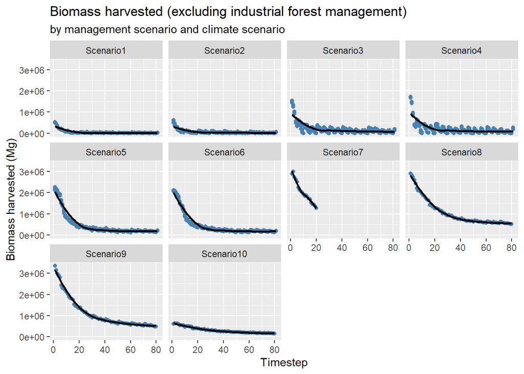

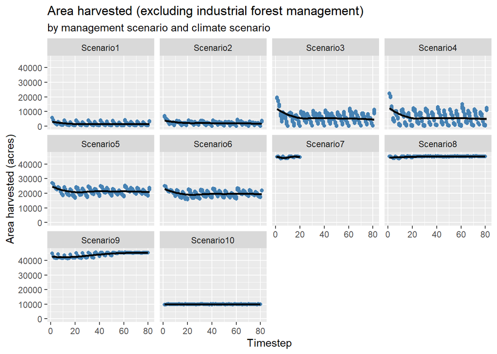

## Biomass patterns

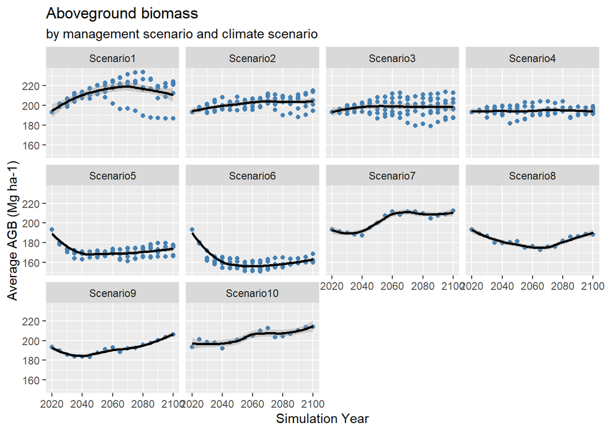

How do biomass distributions compare between scenarios?

The maps below show the proportion of maximum site biomass that is present at year 80 of the model run (Year 2100). The goals are to keep biomass below 60% max (Scenario 9) or 35% max biomass (Scenarios 7, 8, 10).

In general, from scenarios 1 through 6, the area which is below 35% max biomass or 60% max biomass increases as treatment intensity increases. Scenarios 7-10 have varying amounts of proportional biomass, but generally failed to maintain most of the landscape below 35% or 60% max biomass. They have similar patterns to scenarios 3 or 4. Despite the high biomass initially removed in the first few decades of the model run, it appears that thinning primarily young shade-tolerant conifers, without prescribed fire, is insufficient to keep biomass within the target range.

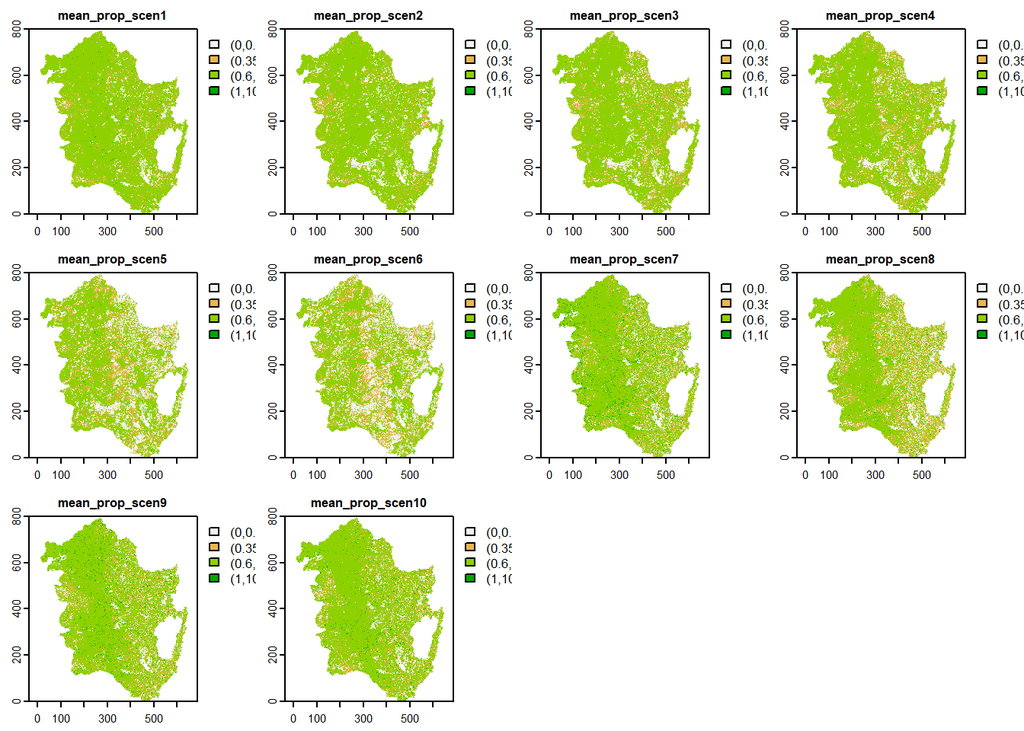

## Fire dynamics

Scenarios 7-10 have a similar cumulative amount of biomass burned by wildfire, though scenarios 7 and 9 are likely to have less than other scenarios (comparable to scenario 6).

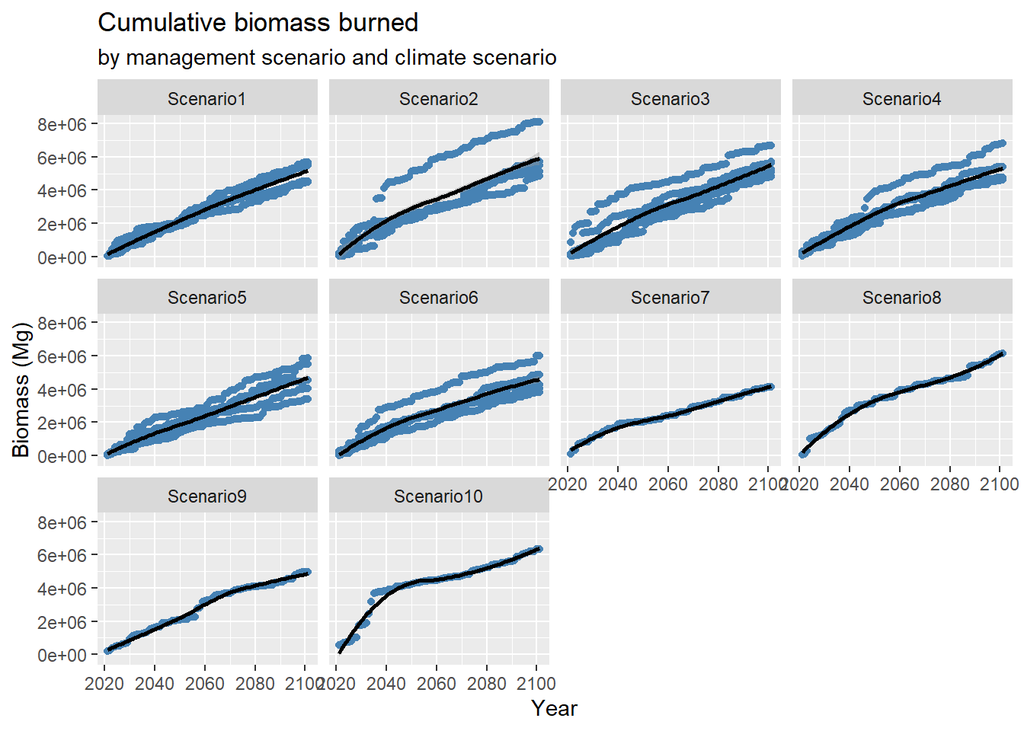

The new scenarios do seem to have an impact on fire severity.

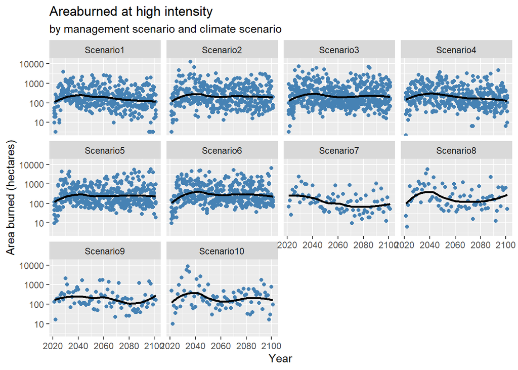

## Beetles

In comparison to the existing scenarios, the new scenarios do little to reduce mortality caused by bark beetle outbreaks, though they do change the temporal pattern of outbreaks.

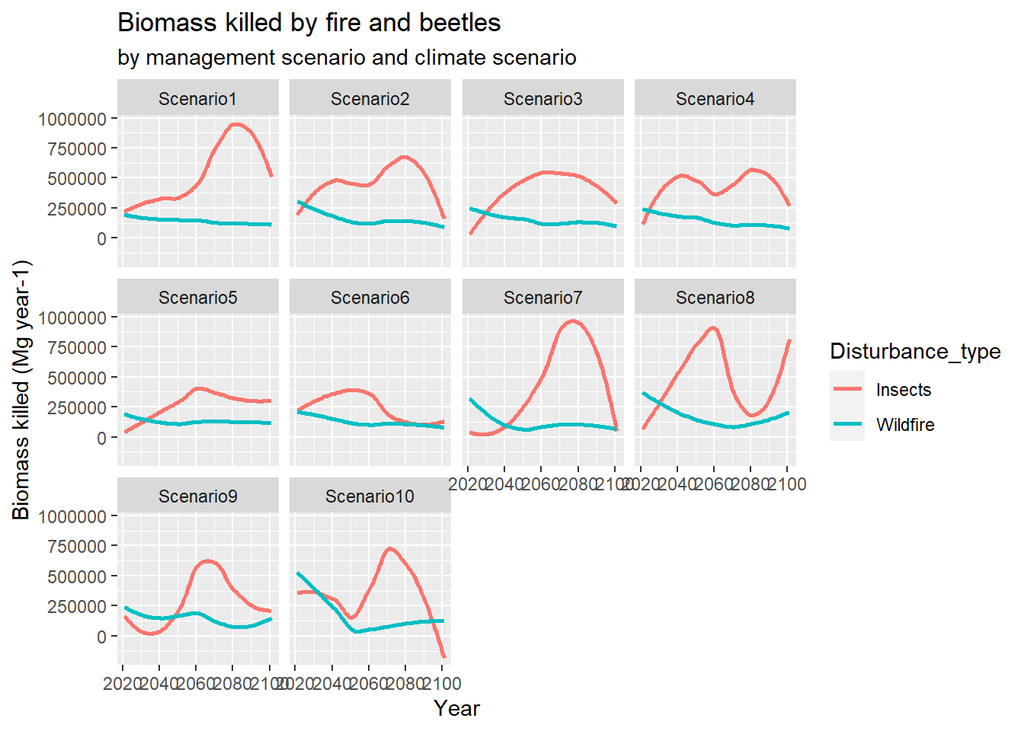

The cumulative mortality from beetles puts the new scenarios in the middle of the pack, similar to scenarios 3 or 4.

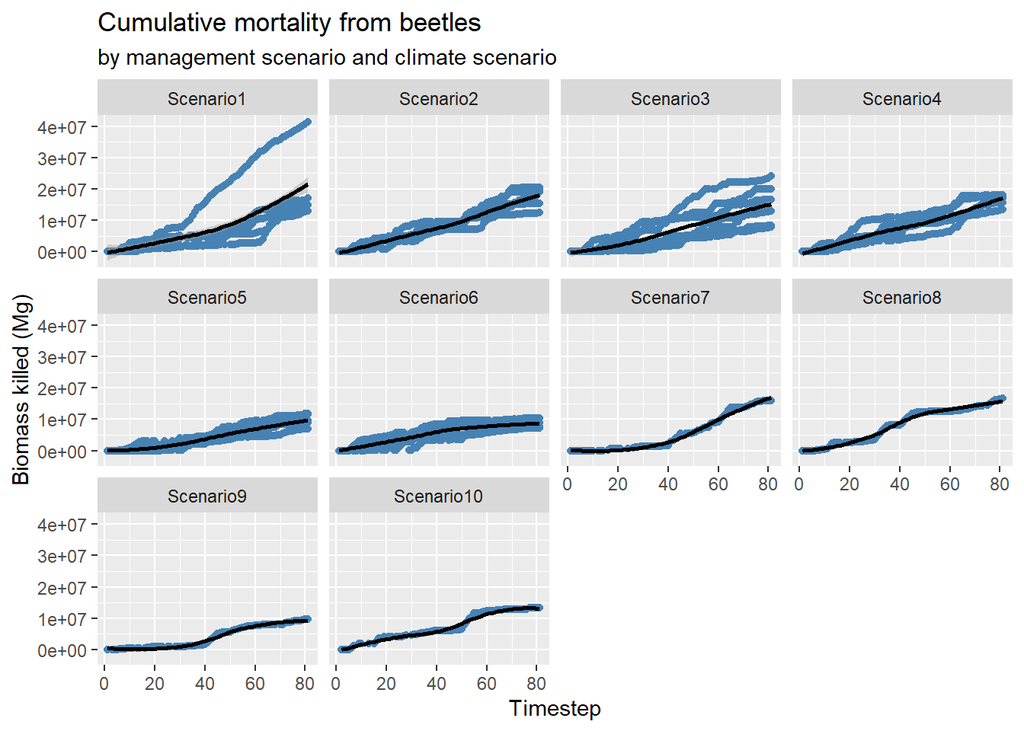

## Summary

Scenarios 7-10 have some potential to be effective at reducing severe wildfire and mortality caused by insect outbreaks. To effectively reduce stand density to the targeted 35% or 60% max biomass, the scenarios will need to be modified to include either 1) treatments that remove older tree cohorts, or 2) include prescribed fire.